# Laboratorio 2: Exploración y Visualización de Datos

Fecha: Marzo 2024

Integrantes: **Nicolás Rodrigo Arancibia Aguirre (Sección 1), Da Ye Kang Kim (Sección 1)**

## Declaración de compromiso ético

Nosotros/as **Nicolás Rodrigo Arancibia Aguirre , Da Ye Kang Kim** , declaramos que realizamos de manera grupal los pasos de la presente actividad. También declaramos no incurrir en copia, ni compartir nuestras respuestas con otras personas ni con otros grupos. Por lo que, ratificamos que las respuestas son de nuestra propia confección y reflejan nuestro propio conocimiento.

## Instrucciones

1. Trabajen en equipos de dos personas. Salvo excepciones, no se corregirá entregas con menos de dos integrantes.
2. Modifique este archivo `.ipynb` agregando sus respuestas donde corresponda. Puede ocupar Jupyter notebook en su computador o usar Google Colab como alternativa online.
3. Para cada pregunta **incluya el código fuente que utilizó para llegar a su respuesta. Respuestas sin código no recibirán puntaje.**.
4. El formato de entrega para esta actividad es un archivo **html**. **Genere un archivo HTML usando Jupyter** y súbalo a U-Cursos. Basta con que un/a integrante haga la entrega. Si ambos/as hacen una entrega en U-Cursos, se revisará cualquiera de éstas.

# Práctica

## Accidentes de tránsito

Para esta sección utilizaremos un dataset real de número de accidentes de tránsito por localidad, el cual puede ser encontrado en el siguiente link: http://datos.gob.cl/dataset/9348. Para cargar el dataset ejecute el siguiente código:

```python
import pandas as pd
import matplotlib.pyplot as plt
```

```python
tipos = pd.read_csv("https://users.dcc.uchile.cl/~hsarmien/mineria/datasets/accidentes_2010_2011.txt", sep=" ")
tipos.head()
```

|  | Muestra | Descripcion | Anio | TipoAccidente | Cantidad |
| --- | --- | --- | --- | --- | --- |
| 1 | Nacional | Nacional | 2010 | Atropello | 8247 |
| 2 | Nacional | Nacional | 2011 | Atropello | 8339 |
| 3 | Regional | XV Región Arica y Parinacota | 2010 | Atropello | 115 |
| 4 | Regional | XV Región Arica y Parinacota | 2011 | Atropello | 159 |
| 5 | Comunal | ARICA | 2010 | Atropello | 115 |

Explore el set de datos para responder las siguientes preguntas:

1. ¿Cuáles son las dimensiones del dataset (filas, columnas)? (Recuerde adjuntar código).

```python
tipos.shape
```

```
(4296, 5)
```

Las dimensiones del dataset son (4296, 5)

2. ¿Qué describe cada línea del dataset? (ejemplifique tomando el dato de la fila 235, extienda la descripción)

```python
tipos.iloc[235, :]
```

```
Muestra            Comunal
Descripcion       PALMILLA
Anio                  2011
TipoAccidente    Atropello
Cantidad                 6
Name: 236, dtype: object
```

Cada línea del dataset entrega información acerca del tipo de muestra de la recolección de datos, la descripción muestra el lugar (más específico en lo posible) donde ocurrió el accidente, el año en que ocurrio el accidente, el tipo de accidente, y por último la cantidad de veces que ocurrió el accidente según los datos previos.

3. ¿Cuántos años diferentes abarca la información del dataset? Entregue un array con los años.

```python
tipos['Anio'].unique()
```

```
array([2010, 2011], dtype=int64)
```

La información del dataset abarca dos años distintos, los años 2010 y 2011.

4. Filtre los datos para incluir sólo los accidentes ocurridos el año 2011 a nivel Regional. Luego, genere un gráfico de barras que muestre la cantidad de accidentes en cada Región. Comente sus principales observaciones y si considera que es razonable usar el conteo de frecuencias para determinar las regiones que tuvieron más accidentes.

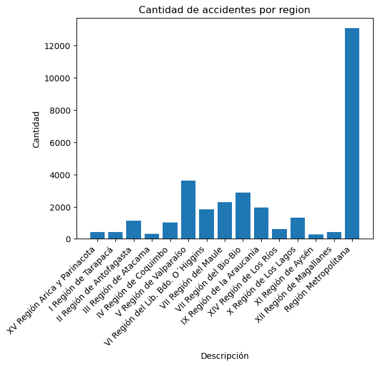

```python
tipos_2011 = tipos[tipos['Anio'] == 2011]
tipos_d = tipos_2011[tipos_2011['Muestra'] == 'Regional']
plt.bar(tipos_d['Descripcion'], tipos_d['Cantidad'])
plt.xlabel('Descripción')
plt.ylabel('Cantidad')
plt.title('Cantidad de accidentes por region')
plt.xticks(rotation=45, ha='right')
plt.show()
```

R: Podemos notar que la región con mayor cantidad de accidentes en Chile durante el año 2011 fue la Región Metropolitana. Sí consideramos que es razonable usar el conteo de frecuencias para determinar las regiones con mayor cantidad de accidentes.

5. Filtre los datos para incluir sólo los accidentes ocurridos el año 2010 a nivel regional. Genere un boxplot donde se indique la cantidad de accidentes categorizado por tipo de accidente. ¿Cuáles son sus principales observaciones?

```python
import plotly.express as px

tipos_2010 = tipos[tipos['Anio'] == 2010]
tipos_d = tipos_2010[tipos_2010['Muestra'] == 'Regional']
fig = px.box(tipos_d, x="TipoAccidente", y="Cantidad")
fig.show()
```

[interactive chart not shown]

Podemos notar que los tipos de accidentes más frecuentes son las colisiones y los choques entre automóviles.

6. ¿Qué otra forma de explorar los datos podría agregar para el dataset de Accidentes de tránsito y qué información adicional aporta? Adjunte el código necesario.

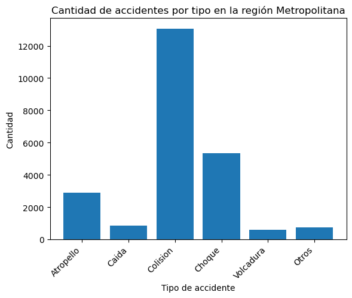

```python
tipos_r = tipos[tipos['Muestra'] == 'Regional']
tipos_rm = tipos_r[tipos_r['Descripcion'] == 'Región Metropolitana']
plt.bar(tipos_rm['TipoAccidente'], tipos_rm['Cantidad'])
plt.xlabel('Tipo de accidente')
plt.ylabel('Cantidad')
plt.title('Cantidad de accidentes por tipo en la región Metropolitana')
plt.xticks(rotation=45, ha='right')
plt.show()
```

Esta forma de explorar los datos del dataset nos entrega información acerca de la cantidad de accidentes en la región metropolitana caracterizada por tipos, y podemos notar que la tendencia que se ve en el boxplot mostrado anteriormente se respetan en particular en la región metropolitana.

## Diabetes

Considere el set de datos de pacientes para la predicción de diabetes con las siguientes columnas:

- gender: género del paciente
- age: edad del paciente
- hypertension: indica si el paciente tiene o no hipertensión
- heart_disease: indica si el paciente tiene o no enfermedad cardiaca
- smoking_history: indica si el paciente es o fue fumador
- bmi: indice de masa corporal del paciente
- HbA1c_level: Hemoglobina HbA1c del paciente
- blood_glucose_level: Nivel de glucosa en sangre del paciente
- diabetes: si el paciente tiene o no diabetes

```python
diabetes = pd.read_csv("https://raw.githubusercontent.com/mzambrano1/Datasets-CC5205-otono-2023/master/lab1.2%202023-2/diabetes_prediction_dataset.csv")
diabetes.head()
```

|  | gender | age | hypertension | heart_disease | smoking_history | bmi | HbA1c_level | blood_glucose_level | diabetes |
| --- | --- | --- | --- | --- | --- | --- | --- | --- | --- |
| 0 | Female | 80.0 | 0 | 1 | never | 25.19 | 6.6 | 140 | 0 |
| 1 | Female | 54.0 | 0 | 0 | No Info | 27.32 | 6.6 | 80 | 0 |
| 2 | Male | 28.0 | 0 | 0 | never | 27.32 | 5.7 | 158 | 0 |
| 3 | Female | 36.0 | 0 | 0 | current | 23.45 | 5.0 | 155 | 0 |
| 4 | Male | 76.0 | 1 | 1 | current | 20.14 | 4.8 | 155 | 0 |

7. Para explorar el dataset, realice un análisis de frecuencias de los atributos categóricos (categorías binarias y multiclase).

```python
f = diabetes[diabetes["gender"] == "Female"].count()
m = diabetes[diabetes["gender"] == "Male"].count()
o = diabetes[diabetes["gender"] == "Other"].count()
print("Female:")
print(f)
print("Male:")
print(m)
print("Other:")
print(o)
```

```
Female:
gender                 58552
age                    58552
hypertension           58552
heart_disease          58552
smoking_history        58552
bmi                    58552
HbA1c_level            58552
blood_glucose_level    58552
diabetes               58552
dtype: int64
Male:
gender                 41430
age                    41430
hypertension           41430
heart_disease          41430
smoking_history        41430
bmi                    41430
HbA1c_level            41430
blood_glucose_level    41430
diabetes               41430
dtype: int64
Other:
gender                 18
age                    18
hypertension           18
heart_disease          18
smoking_history        18
bmi                    18
HbA1c_level            18
blood_glucose_level    18
diabetes               18
dtype: int64
```

```python
female = 58552
male = 41430
other = 18
total = diabetes.shape[0]
print("Porcentaje de mujeres:", 100*female/total,"%")
print("Porcentaje de hombres:", 100*male/total,"%")
print("Porcentaje de otros:", 100*other/total,"%")
```

```
Porcentaje de mujeres: 58.552 %
Porcentaje de hombres: 41.43 %
Porcentaje de otros: 0.018 %
```

Del total de pacientes hay 58552 mujeres, lo que indica que son mayoría dentro del total con un 59% de presencia aproximada, luego le siguen los hombres con 41430 pacientes (el 41% del total), y por último de otros géneros hay 18 pacientes (lo que no llega al 1% del total estudiado).

```python
f = diabetes[diabetes["hypertension"] == 1].count()
m = diabetes[diabetes["hypertension"] == 0].count()
print("Cantidad de personas con hipertensión:")
print(f)
print("Cantidad de personas sin hipertensión:")
print(m)
```

```
Cantidad de personas con hipertensión:
gender                 7485
age                    7485
hypertension           7485
heart_disease          7485
smoking_history        7485
bmi                    7485
HbA1c_level            7485
blood_glucose_level    7485
diabetes               7485
dtype: int64
Cantidad de personas sin hipertensión:
gender                 92515
age                    92515
hypertension           92515
heart_disease          92515
smoking_history        92515
bmi                    92515
HbA1c_level            92515
blood_glucose_level    92515
diabetes               92515
dtype: int64
```

```python
s = 7485
n = 92515
total = diabetes.shape[0]
print("Porcentaje de gente con hipertensión:", 100*s/total,"%")
print("Porcentaje de gente sin hipertensión:", 100*n/total,"%")
```

```
Porcentaje de gente con hipertensión: 7.485 %
Porcentaje de gente sin hipertensión: 92.515 %
```

Hay 92515 pacientes que no tienen hipertensión (un 92,5% del total), lo cual indica que la gran mayoría de personas no sufren de hipertensión, a diferencia del 7.5% restante que sí lo sufre (unos 7485 pacientes).

```python
f = diabetes[diabetes["heart_disease"] == 1].count()
m = diabetes[diabetes["heart_disease"] == 0].count()
print("Cantidad de personas con enfermedades cardiácas:")
print(f)
print("Cantidad de personas sin enfermedades cardiácas:")
print(m)
```

```
Cantidad de personas con enfermedades cardiácas:
gender                 3942
age                    3942
hypertension           3942
heart_disease          3942
smoking_history        3942
bmi                    3942
HbA1c_level            3942
blood_glucose_level    3942
diabetes               3942
dtype: int64
Cantidad de personas sin enfermedades cardiácas:
gender                 96058
age                    96058
hypertension           96058
heart_disease          96058
smoking_history        96058
bmi                    96058
HbA1c_level            96058
blood_glucose_level    96058
diabetes               96058
dtype: int64
```

```python
s = 3942
n = 96058
total = diabetes.shape[0]
print("Porcentaje de personas con enfermedades cardiácas:", 100*s/total,"%")
print("Porcentaje de personas sin enfermedades cardiácas:", 100*n/total,"%")
```

```
Porcentaje de personas con enfermedades cardiácas: 3.942 %
Porcentaje de personas sin enfermedades cardiácas: 96.058 %
```

Hay 96058 pacientes sin enfermedades cardiácas, es decir, el 96% de los pacientes no tienen enfermedades cardiácas, lo cual indica que la gran mayoría de personas no sufren de enfermedades al corazón, a diferencia de los 3942 pacientes restantes que sí padecen de enfermedades cardiácas (un 4% del total aproximadamente).

```python
f = diabetes[diabetes["smoking_history"] == "never"].count()
m = diabetes[diabetes["smoking_history"] == "current"].count()
o = diabetes[diabetes["smoking_history"] == "No Info"].count()
print("Personas que nunca han fumado:")
print(f)
print("Personas que actualmente fuman:")
print(m)
print("Personas de las que no hay información:")
print(o)
```

```
Personas que nunca han fumado:
gender                 35095
age                    35095
hypertension           35095
heart_disease          35095
smoking_history        35095
bmi                    35095
HbA1c_level            35095
blood_glucose_level    35095
diabetes               35095
dtype: int64
Personas que actualmente fuman:
gender                 9286
age                    9286
hypertension           9286
heart_disease          9286
smoking_history        9286
bmi                    9286
HbA1c_level            9286
blood_glucose_level    9286
diabetes               9286
dtype: int64
Personas de las que no hay información:
gender                 35816
age                    35816
hypertension           35816
heart_disease          35816
smoking_history        35816
bmi                    35816
HbA1c_level            35816
blood_glucose_level    35816
diabetes               35816
dtype: int64
```

```python
a = 35095
b = 9286
c = 35816
total = diabetes.shape[0]
print("Porcentaje de no fumadores:", 100*a/total,"%")
print("Porcentaje de fumadores:", 100*b/total,"%")
print("Porcentaje de personas sin información:", 100*c/total,"%")
```

```
Porcentaje de no fumadores: 35.095 %
Porcentaje de fumadores: 9.286 %
Porcentaje de personas sin información: 35.816 %
```

Se puede notar que las personas sin datos/info son mayoría (levemente en el dataset) con 35816 pacientes (un 36% del total aproximadamente), luego le siguen los no fumadores con 35095 (un 35% del total), y finalmente quedan los fumadores con 9286 pacientes (un 9% del total).

```python
f = diabetes[diabetes["diabetes"] == 1].count()
m = diabetes[diabetes["diabetes"] == 0].count()
print("Cantidad de personas con diabetes:")
print(f)
print("Cantidad de personas sin diabetes:")
print(m)
```

```
Cantidad de personas con diabetes:
gender                 8500
age                    8500
hypertension           8500
heart_disease          8500
smoking_history        8500
bmi                    8500
HbA1c_level            8500
blood_glucose_level    8500
diabetes               8500
dtype: int64
Cantidad de personas sin diabetes:
gender                 91500
age                    91500
hypertension           91500
heart_disease          91500
smoking_history        91500
bmi                    91500
HbA1c_level            91500
blood_glucose_level    91500
diabetes               91500
dtype: int64
```

```python
s = 8500
n = 91500
total = diabetes.shape[0]
print("Porcentaje de personas con diabetes:", 100*s/total,"%")
print("Porcentaje de personas diabetes:", 100*n/total,"%")
```

```
Porcentaje de personas con diabetes: 8.5 %
Porcentaje de personas diabetes: 91.5 %
```

Hay 91500 personas sin diabetes, lo que representa un 91.5% del total de pacientes, lo cual indica que la gran mayoría de personas no sufren de diabetes en el dataset, a diferencia de los otros 8500 pacientes (un 8.5% del total) que sí lo sufre.

8. Muestre estadísticas de resumen para las variables numéricas y comenten sus observaciones.

```python
años = diabetes['age']
print("La edad promedio de las personas estudiadas es:", años.mean(), "años.")
```

```
La edad promedio de las personas estudiadas es: 41.885856 años.
```

La edad promedio es de 42 años aproximadamente, lo cual indica que la persona promedio en el estudio es un adulto de mediana edad.

```python
bmi = diabetes['bmi']
print("El índice de masa corporal promedio de las personas estudiadas es de", bmi.mean())
```

```
El índice de masa corporal promedio de las personas estudiadas es de 27.3207671
```

El índice de masa corporal promedio es de 27.32, lo cual nos dice que las personas del estudio en promedio tienen sobrepeso.

```python
level = diabetes['HbA1c_level']
print("La desviación estándar de niveles de Hemoglobina HbA1c en los pacientes es", level.std())
```

```
La desviación estándar de niveles de Hemoglobina HbA1c en los pacientes es 1.0706720918832282
```

La desviación estándar de niveles de Hemoglobina HbA1c es 1.0706720918832282, lo que nos dice que los datos con respecto a los niveles de es esta hemoglobina se desvían del promedio en cierta medida, tampoco es que sean muy diferentes en grandes cantidades.

```python
l = diabetes['blood_glucose_level']
print("El nivel de glucosa en la sangre promedio de las personas estudiadas es de", l.mean())
```

```
El nivel de glucosa en la sangre promedio de las personas estudiadas es de 138.05806
```

El nivel de glucosa en la sangre promedio de los pacientes es de 138, lo cual nos indica que en promedio los pacientes tienen un mayor cantidad de glucosa en la sangre de la que debiése tener una persona sana.

Y eso es todo por hoy :)